# Lab4

## Assignment 2: Investigate the prediction properties of the Random Forest method on highly correlated data

In Lab 2_2, you investigated how PCR, PLS, Lasso and Ridge regression performed on the “tecator.csv” data which contains the results of a study aimed to investigate whether a near infrared absorbance spectrum can be used to predict the fat content of samples of meat. It has been noticed that the Random Forest (RF) method can be sensitive to correlated data, and it has been suggested that the mtry parameter can be tuned to lower values to improve prediction properties. Your task is to check if this is true by implementing the RF with the combination of the randomForest and caret packages.

Start by explaining in detail what the mtry parameter has for role in the RF method. Then, follow the instructions for loading and editing of the data set in Lab 2_2. Set up the train model in the caret packages with 25-fold CV. Evaluate models over mtry with a sequence of values from 1 to 25. You can leave the ntrees and nodesize parameters at their default values. Is there any evidence for the claim that lower mtry yields lower prediction accuracy? Which is the best model and how does the prediction MSE compare with the estimates from Lab 2_2 PCR, PLS, Lasso and Ridge regression? What is your conclusion regarding the RF and correlated data?

#### Pre

```r
tecator = read.csv("/Users/tuuba/code/ISRL/Lab2/tecator.csv")
tecator_subset = tecator[ , !names(tecator) %in% c('Sample', 'Protein', 'Moisture')]
```

```r
library(randomForest)
control <- trainControl(method='cv',
                        number=25,
                        search = 'grid')

#Number randomely variable selected is mtry
mtry <- 1:25
tunegrid <- expand.grid(.mtry=mtry)
rf_model <- train(Fat~.,
                  data=tecator_subset,
                  method='rf',
                  metric = 'RMSE',
                  tuneGrid=tunegrid,
                  trControl=control)
```

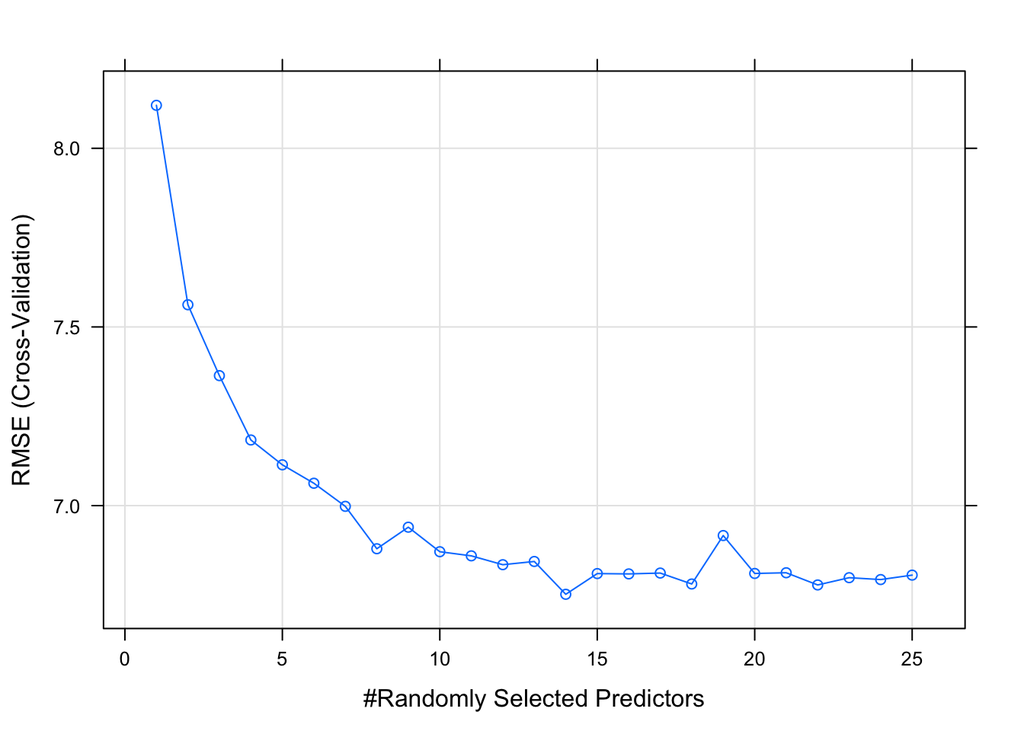

```r
plot(rf_model)
```

```r
mse_model = min(rf_model$results$RMSE) ** 2
# cat(sprintf('RF Best MSE: %.2f', mse_model))
```